# Utilities for markers and DEGs from scRUtils

I-Hsuan Lin

07/29/2026

#### Package

scRUtils 0.4.2

# 1 Overview

`scRUtils` provides various utilities for visualising and functional analysis of RNA-seq data, particularly single-cell dataset. It evolved from a collection of helper functions that were used in our in-house scRNA-seq processing workflow.

The documentation of this package is divided into 5 sections:

1. [Introduction to scRUtils](https://ycl6.github.io/scRUtils/scRUtils-intro.html)
2. [General data visualisations](https://ycl6.github.io/scRUtils/basics.html)
3. [Single-cell visualisations](https://ycl6.github.io/scRUtils/singleCell.html)
4. [Markers and DEGs](https://ycl6.github.io/scRUtils/markers.html)
5. [Demo datasets](https://ycl6.github.io/scRUtils/demoData.html)

This vignette (#4) will demonstrate functions for markers and DEGs identified from single-cell datasets.

# 2 Load packages

To use `scRUtils` and relevant packages in a R session, we load them using the `library()` command.

```r
library(scRUtils)

library(ggplot2)
library(scater)
```

# 3 Markers and DEGs

## 3.1 Print marker gene stats from `findMarkers` output

The `printMarkerStats()` function parses the `findMarkers()` output (from the *scran* package) and print the number of marker genes that “passed” the `fdr` or `top` threshold on to standard output in interactive sessions. It provides a quick way to find out the number of candidate marker genes.

The function can detect the `pval.type` and `test.type`, to a certain degree, based on the resulting DataFrame structure. One can optionally provide the `pval.type` and `min.prop` settings used to run `findMarkers()` to allow `printMarkerStats()` to use them in the printed messages.

The `sce` demo has four `findMarkers()` results stored in the `metadata` slot:

1. running `findMarkers()` with `pval.type = "any"`
2. running `findMarkers()` with `pval.type = "all"`
3. running `findMarkers()` with `pval.type = "any"` and `min.prop = 0.5`
4. running `findMarkers()` with `test.type = "wilcox"`

### 3.1.1 With `pval.type = "any"`

```r
data(sce)

# Show 1st DataFrame in the list
# DataFrame(metadata(sce)[["findMarkers1"]][[1]])
printMarkerStats(metadata(sce)[["findMarkers1"]])
```

```
## Number of selected markers (Top 200 genes of any 1 comparison):
## - A: 495; Up = 248; Down = 247; Max. P-value = 0.38.
## - B: 522; Up = 250; Down = 272; Max. P-value = 0.37.
## - C: 475; Up = 227; Down = 248; Max. P-value = 0.35.
## - D: 489; Up = 235; Down = 254; Max. P-value = 0.36.
## - E: 506; Up = 245; Down = 261; Max. P-value = 0.19.
## * Upregulated when logFC > 0.0 and downregulated when logFC < 0.0.
```

### 3.1.2 With `pval.type = "all"`

```r
# Show 1st DataFrame in the list
# DataFrame(metadata(sce)[["findMarkers2"]][[1]])
printMarkerStats(metadata(sce)[["findMarkers2"]])
```

```
## Number of selected markers (FDR at 0.05):
## - A: 19; Up = 12; Down = 7; Max. P-value = 0.00046.
## - B: 25; Up = 22; Down = 3; Max. P-value = 0.0011.
## - C: 27; Up = 16; Down = 11; Max. P-value = 0.0012.
## - D: 20; Up = 16; Down = 4; Max. P-value = 0.00051.
## - E: 23; Up = 16; Down = 7; Max. P-value = 0.00069.
## * Upregulated when logFC > 0.0 and downregulated when logFC < 0.0.
```

### 3.1.3 With `pval.type = "any"` and `min.prop = 0.5`

```r
# Show 1st DataFrame in the list
# DataFrame(metadata(sce)[["findMarkers3"]][[1]])
printMarkerStats(metadata(sce)[["findMarkers3"]], min.prop = 0.5)
```

```
## Number of selected markers (Top 200 genes of at least 50.0% comparisons):
## - A: 164; Up = 80; Down = 84; Max. P-value = 0.075.
## - B: 151; Up = 76; Down = 75; Max. P-value = 0.18.
## - C: 171; Up = 82; Down = 89; Max. P-value = 0.18.
## - D: 171; Up = 69; Down = 102; Max. P-value = 0.19.
## - E: 163; Up = 77; Down = 86; Max. P-value = 0.16.
## * Upregulated when logFC > 0.0 and downregulated when logFC < 0.0.
```

### 3.1.4 With `test.type = "wilcox"`

```r
# Show 1st DataFrame in the list
# DataFrame(metadata(sce)[["findMarkers4"]][[1]])
printMarkerStats(metadata(sce)[["findMarkers4"]])
```

```
## Number of selected markers (Top 200 genes of any 1 comparison):
## - A: 155; Up = 80; Down = 75; Max. P-value = 0.0038.
## - B: 166; Up = 54; Down = 112; Max. P-value = 0.0015.
## - C: 162; Up = 43; Down = 119; Max. P-value = 0.0038.
## - D: 152; Up = 66; Down = 86; Max. P-value = 0.0025.
## - E: 147; Up = 63; Down = 84; Max. P-value = 0.0026.
## * Upregulated when AUC > 0.7 and downregulated when AUC < 0.3.
```

## 3.2 Retrieve marker genes from a `findMarkers` output DataFrame

The `getMarkers()` function parses a `findMarkers()` output DataFrame and returns the up- and down-regulated marker genes that passed the specified threshold.

By specifying `direction`, the function selects up-regulated markers when `direction = "up"`, down-regulated markers when `direction = "down"` and both up- and down-regulated markers when `direction = "both"` (default). The definition of up/down-regulation depends on the `test.type` used when running `findMarkers()`.

The example below retrieves first 1000 markers (default `max`) from the 1st DataFrame (Cluster A) in ‘findMarkers1’, return rownames. There will only be 495 genes returned as shown in the `printMarkerStats()` message.

```r
genes <- getMarkers(metadata(sce)[["findMarkers1"]][[1]])
length(genes)
```

```
## [1] 495
```

```r
head(genes)
```

```
## [1] "OOX46" "VWF23" "BFP78" "DKD62" "VVU55" "CBL62"
```

Next example retrieves first 1000 up-regulated markers (default `max`) from the 2nd DataFrame (Cluster B) in ‘findMarkers4’, return rownames. There will only be 54 genes returned as shown in the `printMarkerStats()` message.

```r
genes <- getMarkers(metadata(sce)[["findMarkers4"]][[2]], direction  = "up")
length(genes)
```

```
## [1] 54
```

```r
head(genes)
```

```
## [1] "OOX46" "CVH52" "KGI33" "BNU44" "SQS49" "IKP74"
```

## 3.3 Retrieve differentially expressed genes from edgeR or DESeq2 analysis

The `getDEGs()` function parses an object of class `TopTags`, `DGEExact` or `DGELRT` from *edgeR* or `DESeqResults` class from *DESeq2*, and returns the differentially expressed genes (DEGs) that passed the specified thresholds.

As with `getMarkers()`, by specifying `direction`, the function selects DEGs with a positive and negative logFC when `direction = "both"` (default), only positive logFC when `direction = "up"`, and only negative logFC when `direction = "down"`.

The example below retrieves first 250 up-regulated DEGs from DESeq2’s output, return rownames (Ensembl ID).

```r
data(res_deseq2)

genes <- getDEGs(res_deseq2, direction = "up", max = 250)
length(genes)
```

```
## [1] 250
```

```r
head(genes)
```

```
## [1] "FBgn0000043" "FBgn0000064" "FBgn0000071" "FBgn0000116" "FBgn0000146"
## [6] "FBgn0000147"
```

Next example retrieves first 1000 DEGs (default `max`) at FDR = 10% from edgeR’s output, return values from the `external_gene_name` column (Gene Symbol).

```r
data(res_edger)

genes <- getDEGs(res_edger, fdr = 0.1, column_by = "external_gene_name")
length(genes)
```

```
## [1] 1000
```

```r
head(genes)
```

```
## [1] "Kal1"   "Ant2"   "sesB"   "CG1544" "CG3770" "SPARC"
```

## 3.4 Export results from findMarkers, edgeR or DESeq2 to tsv

When `concatenate = TRUE`, the function concatenate the test statistics from results stored in the list and outputs a single file.

The example below saves the results from ‘findMarkers1’ into individual files in the per-session temporary directory `tempdir()`.

```r
exportResList(metadata(sce)[["findMarkers1"]], dir_path = tempdir())
```

```
## Detecting findMarkers input.
## Creating file: output_findMarkers_A.tsv
## Creating file: output_findMarkers_B.tsv
## Creating file: output_findMarkers_C.tsv
## Creating file: output_findMarkers_D.tsv
## Creating file: output_findMarkers_E.tsv
```

Next we use `concatenate = TRUE` save the concatenated results from ‘findMarkers4’ in the per- session temporary directory `tempdir()`.

```r
exportResList(metadata(sce)[["findMarkers4"]], concatenate = TRUE,
              prefix = "wilcox", dir_path = tempdir())
```

```
## Detecting findMarkers input.
## Creating a concatenated file: wilcox_findMarkers_concatenated.tsv
```

# 4 Enrichment analysis with `enrichR`

## 4.1 Perform enrichR analysis on results from findMarkers, edgeR or DESeq2

The `runEnrichR()` function takes a list of objects containing `findMarkers()`, *edgeR* or *DESeq2* results, and perform enrichment analysis on the genes that passed the specified threshold.

`runEnrichR()` uses `enrichr()` from the *enrichR* package to submit gene symbols for enrichment analysis to the [Enrichr website](https://maayanlab.cloud/Enrichr). By default (with `column_by = NULL`), this function extracts rownames from the input DataFrames and submits the acquired strings for the analysis.

The gene symbols are submitted to the main site (`site = "Enrichr"`) with gene sets compiled from human and mouse genes. By change the `site` setting, it can use other [modEnrichr sites](https://maayanlab.cloud/modEnrichr/) suitable for other model organisms.

In the example below, we construct a list of 3 DataFrames using the same DESeq2 output (`res_deseq2`) to mimic having a list containing results from multiple sets of comparisons. As `pasilla` is a RNA-seq dataset from *Drosophila melanogaster*, we change the `site` argument to `"FlyEnrichr"` to carry out the analysis.

```r
# Construct a list of results to run analysis
res.de <- list(A_B = res_deseq2, A_C = res_deseq2, B_C = res_deseq2)

# Select gene-set libraries
dbs <- c("GO_Molecular_Function_2018", "GO_Biological_Process_2018")

# Run enrichR
# Specify the gene symbols are stored in the 'external_gene_name' column
res.ora <- runEnrichR(res.de, dbs = dbs, site = "FlyEnrichr",
                      column_by = "external_gene_name")
```

```
## Welcome to enrichR
## Checking connections ...
```

```
## Enrichr ... Connection is Live!
## FlyEnrichr ... Connection is Live!
## WormEnrichr ... Connection is Live!
## YeastEnrichr ... Connection is Live!
## FishEnrichr ... Connection is Live!
## OxEnrichr ... Connection is Live!
## Detecting DESeq2 input.Connection changed to https://maayanlab.cloud/FlyEnrichr/
## Connection is Live!
## Running enrichR on 'A_B' with 983 up- and down-regulated genes.
```

```
## Uploading data to Enrichr... Done.
##   Querying GO_Molecular_Function_2018... Done.
##   Querying GO_Biological_Process_2018... Done.
## Parsing results... Done.
```

```
## Running enrichR on 'A_C' with 983 up- and down-regulated genes.
```

```
## Uploading data to Enrichr... Done.
##   Querying GO_Molecular_Function_2018... Done.
##   Querying GO_Biological_Process_2018... Done.
## Parsing results... Done.
```

```
## Running enrichR on 'B_C' with 983 up- and down-regulated genes.
```

```
## Uploading data to Enrichr... Done.
##   Querying GO_Molecular_Function_2018... Done.
##   Querying GO_Biological_Process_2018... Done.
## Parsing results... Done.
```

The returned object `res.ora` is a named list of list of DataFrames:

- On the top-level are lists with names from original DESeq2 input, i.e. “A_B, A_C, B_C”.
- In each of them are lists with the names of selected gene-set libraries, i.e. “GO_Molecular_Function_2018, GO_Biological_Process_2018”.
- Finally, in each is a DataFrame containing the enrichment results from a gene-set libraries.

```r
names(res.ora)
```

```
## [1] "A_B" "A_C" "B_C"
```

```r
names(res.ora[["A_B"]])
```

```
## [1] "GO_Molecular_Function_2018" "GO_Biological_Process_2018"
```

```r
str(res.ora[["A_B"]][["GO_Molecular_Function_2018"]])
```

```
## 'data.frame':    435 obs. of  9 variables:
##  $ Term                : chr  "lipid-transporting ATPase activity (GO:0034040)" "sterol-transporting ATPase activity (GO:0034041)" "imaginal disc growth factor receptor binding (GO:0008084)" "anion:anion antiporter activity (GO:0015301)" ...
##  $ Overlap             : chr  "6/10" "6/10" "4/7" "4/8" ...
##  $ P.value             : num  2.46e-06 2.46e-06 1.80e-04 3.46e-04 2.99e-07 ...
##  $ Adjusted.P.value    : num  0.000214 0.000214 0.004693 0.007532 0.000114 ...
##  $ Old.P.value         : num  0.000659 0.000659 0.006344 0.00897 0.000211 ...
##  $ Old.Adjusted.P.value: num  0.0573 0.0573 0.2509 0.3038 0.0573 ...
##  $ Z.score             : num  -3.17 -3.04 -4.23 -4.56 -1.85 ...
##  $ Combined.Score      : num  40.9 39.2 36.4 36.3 27.8 ...
##  $ Genes               : chr  "CG5853;CG3164;CG9663;CG31689;CG4822;Atet" "CG5853;CG3164;CG9663;CG31689;CG4822;Atet" "Idgf1;Idgf4;Idgf3;Idgf6" "sesB;Ant2;Prestin;Ndae1" ...
```

## 4.2 Visualise Enrichr results as barplots

The `plotEnrichR()` function takes a list of list of DataFrames containing Enrichr results returned by `runEnrichR()` and create barplots from a selected gene-set library.

It prints barplots from each group of comparison using `grid.draw()` from the *grid* package one after another, therefore the plotting feature is suitable only in Jupyter Notebook or R Markdown. Otherwise, disable plotting by specifying the `prefix` argument to save barplots to PDF files.

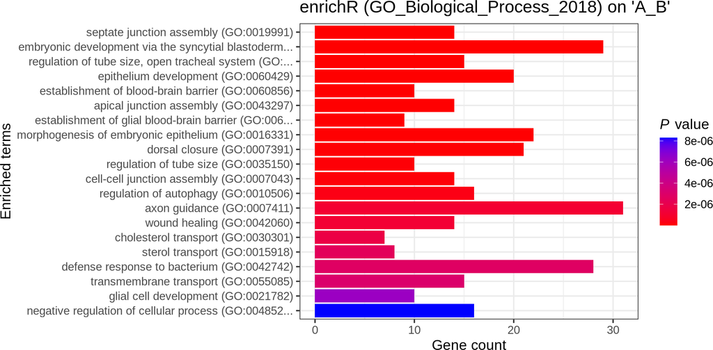

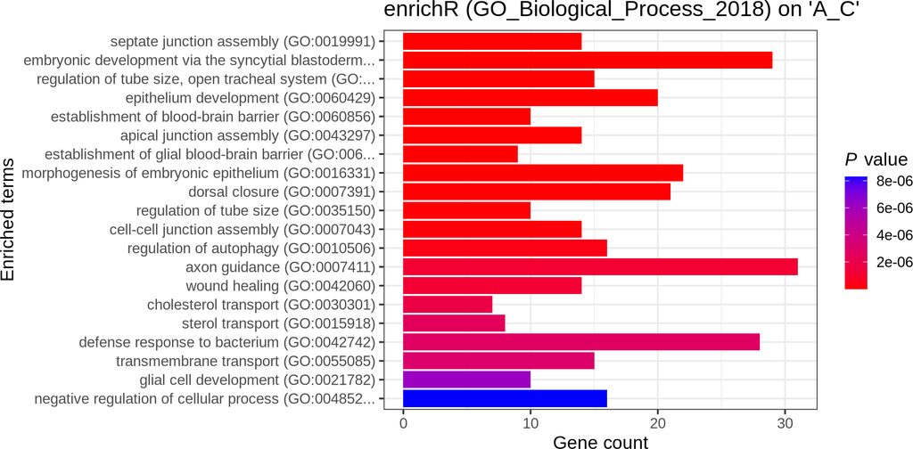

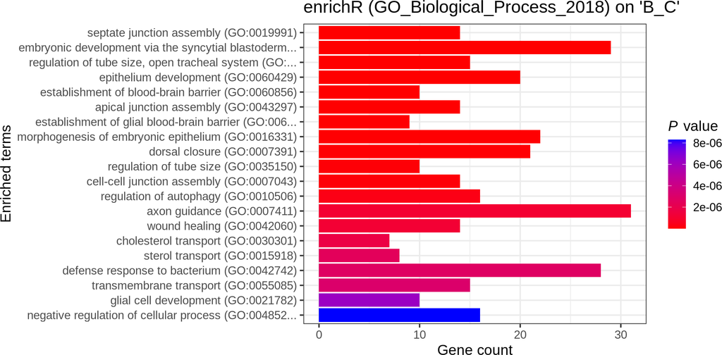

```r
plotEnrichR(res.ora, db = "GO_Biological_Process_2018", theme_size = 14)
```

Alternatively, we can export barplots to PDF files in the per-session temporary directory `tempdir()` as shown below.

```r
plotEnrichR(res.ora, db = "GO_Biological_Process_2018", prefix = "Enrichr",
            dir_path = tempdir(), width = 12, height = 5)
```

```
## Creating file: Enrichr_A_B_GO_Biological_Process_2018.pdf
## Creating file: Enrichr_A_C_GO_Biological_Process_2018.pdf
## Creating file: Enrichr_B_C_GO_Biological_Process_2018.pdf
```

## 4.3 Export results from Enrichr to tsv

The `printEnrichR()` function takes a list of list of DataFrames containing Enrichr results returned by `runEnrichR()` and save all the results in the list object to individual text files.

We are not using `printEnrich()` from the *enrichR* package to print results due to a bug not yet fixed in the current verion in CRAN at the time of writing (v3.0).

```r
printEnrichR(res.ora, prefix = "Enrichr", dir_path = tempdir())
```

```
## Creating file: Enrichr_A_B_GO_Molecular_Function_2018.tsv
## Creating file: Enrichr_A_B_GO_Biological_Process_2018.tsv
## Creating file: Enrichr_A_C_GO_Molecular_Function_2018.tsv
## Creating file: Enrichr_A_C_GO_Biological_Process_2018.tsv
## Creating file: Enrichr_B_C_GO_Molecular_Function_2018.tsv
## Creating file: Enrichr_B_C_GO_Biological_Process_2018.tsv
```